# Home assignment - nycflights

Zoltan Aszalos

February 6, 2017

#### Tasks for this assignment:

### 1. Exploratory data analysis on the available features

Overview of the general information on data in 3 data sets (Airlines, Airports and Flights )

### 2. A model predicting if a flight will be late by 15+ minutes at the destination

Based on information on late flights applying the random forest model

The key question of this exercise is to identify factors leading to late arrivals. It is to note that some factors with a potential impact on delays are not included in these 3 tables, and also not included in any of the 5 data sets: e.g. the number of runways at an airport, quality of air / flight control services, check-in and baggage services.

### 1. Exploratory data analysis on the available features

This first chapter includes a quick exploration of data in 3 data sets: 1 airlines 2 airports 3 flights

What the statistics reveals:

## ARLINES: Data set on 16 airlines

[output not shown]

This data set includes the abbreviated name of 16 airlines in the US. These are the main airlines of the US. For a complete list of US airlines, including regional airlines please visit Wikipedia: [link](https://en.wikipedia.org/wiki/List_of_airlines_of_the_United_States)

The association plot shows the deviation of the number of flights of different carriers from the three airports of origin.

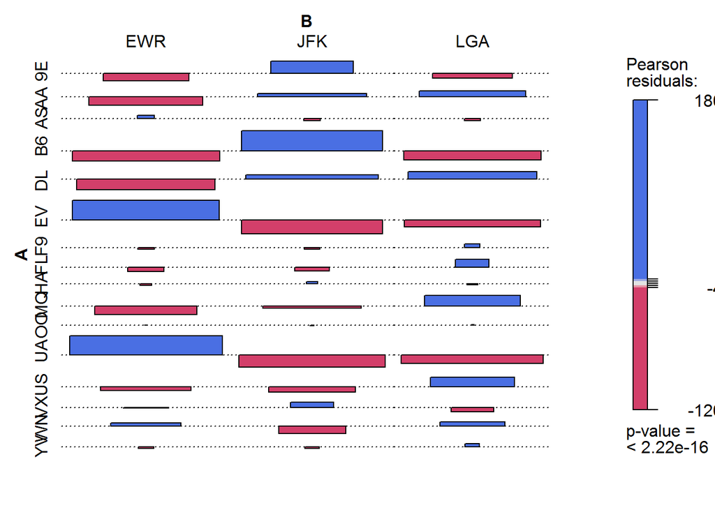

## AIRPORTS: Dataset on 1,458 airports

This is a data set presenting the geographic location, the altitude and the time zone of the airports: the origin and destination airports represented in the flights dataset. The three origin aiports are all around New York City: JFK - New York, LaGuardia - New York and EWR - New Jersey.

The distribution of aiports at various altitute levels is shows by the below chart.

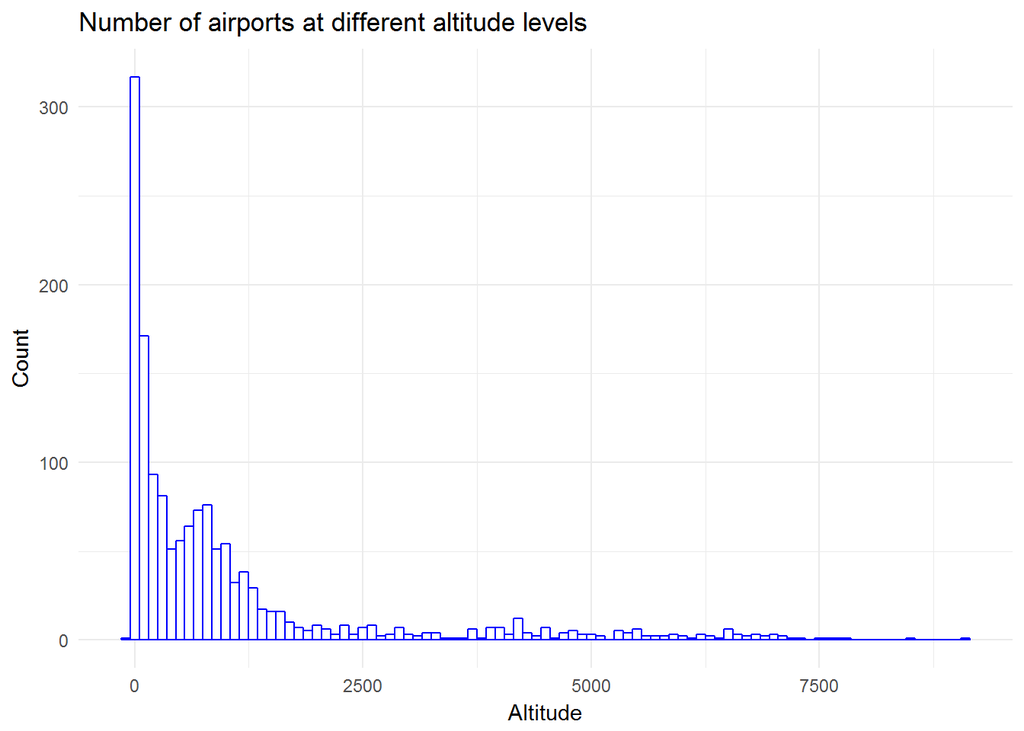

This graph shows that the airports are dominantly close to sea level, with some exceptions (max hight is 9078 feeet above sea level). From this dataset we will explore the potential impact of one factor on flight delays: altitudes.

As part of data exploration the below chart shows the longitude of the airports. It reveals the dominance of flights of East Coast to flights on the West Coast.

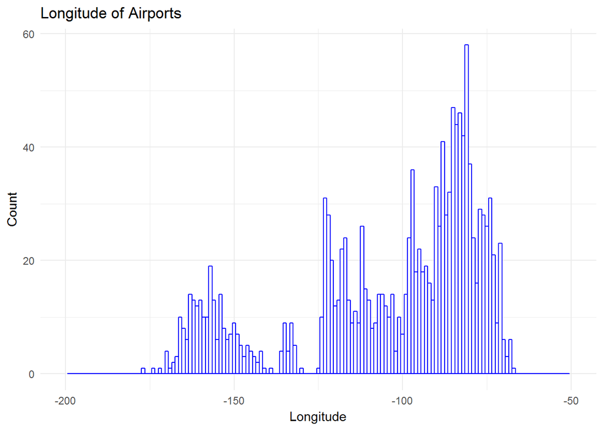

# FLIGHTS: Data set on 336776 flights to and from the 3 New York airports

```
## # A tibble: 336,776 × 19
##     year month   day dep_time sched_dep_time dep_delay arr_time
##    <int> <int> <int>    <int>          <int>     <dbl>    <int>
## 1   2013     1     1      517            515         2      830
## 2   2013     1     1      533            529         4      850
## 3   2013     1     1      542            540         2      923
## 4   2013     1     1      544            545        -1     1004
## 5   2013     1     1      554            600        -6      812
## 6   2013     1     1      554            558        -4      740
## 7   2013     1     1      555            600        -5      913
## 8   2013     1     1      557            600        -3      709
## 9   2013     1     1      557            600        -3      838
## 10  2013     1     1      558            600        -2      753
## # ... with 336,766 more rows, and 12 more variables: sched_arr_time <int>,
## #   arr_delay <dbl>, carrier <chr>, flight <int>, tailnum <chr>,
## #   origin <chr>, dest <chr>, air_time <dbl>, distance <dbl>, hour <dbl>,
## #   minute <dbl>, time_hour <dttm>
```

This dataset is the central dataset. The columns in this data frame:

- year,month,day: Date of departure
- dep_time,arr_time: Actual departure and arrival times, local tz.
- sched_dep_time,sched_arr_time: Scheduled departure and arrival times, local tz.
- dep_delay,arr_delay: Departure and arrival delays, in minutes. Negative times represent early departures/arrivals.
- hour,minute: Time of scheduled departure broken into hour and minutes.
- carrier: Two letter carrier abbreviation. See the “airlines” data set to get name
- tailnum: Plane tail number
- flight: Flight number
- origin, dest: Origin and destination. See airports for additional metadata.
- air_time: Amount of time spent in the air, in minutes
- distance: Distance between airports, in miles
- time_hour: Scheduled date and hour of the flight as a POSIXct date. Along with origin, can be used to join flights data to weather data.

Analysis reveals the following information:

- Some flights arrive early, the earliest is -86 minutes early in the database, and some flights are late, the latest was 1272 minutes late.
- On average, flights are late with 6.8953768 minutes.
- Out of the 336,776 flights in the database, there are 77,630 cases of late arrivals over 15 minutes.

The below chart on the distribution of actual departure times during the day shows a peak of flights in the morning and another peak in the afternoon.

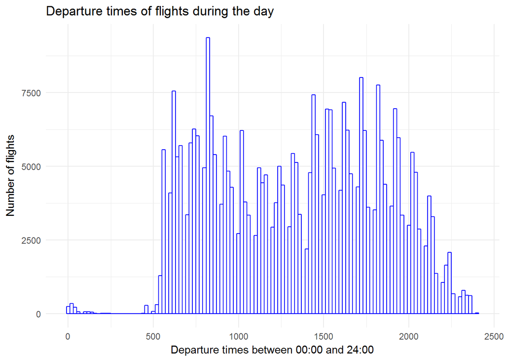

And another distribution chart on arrivals during the day:

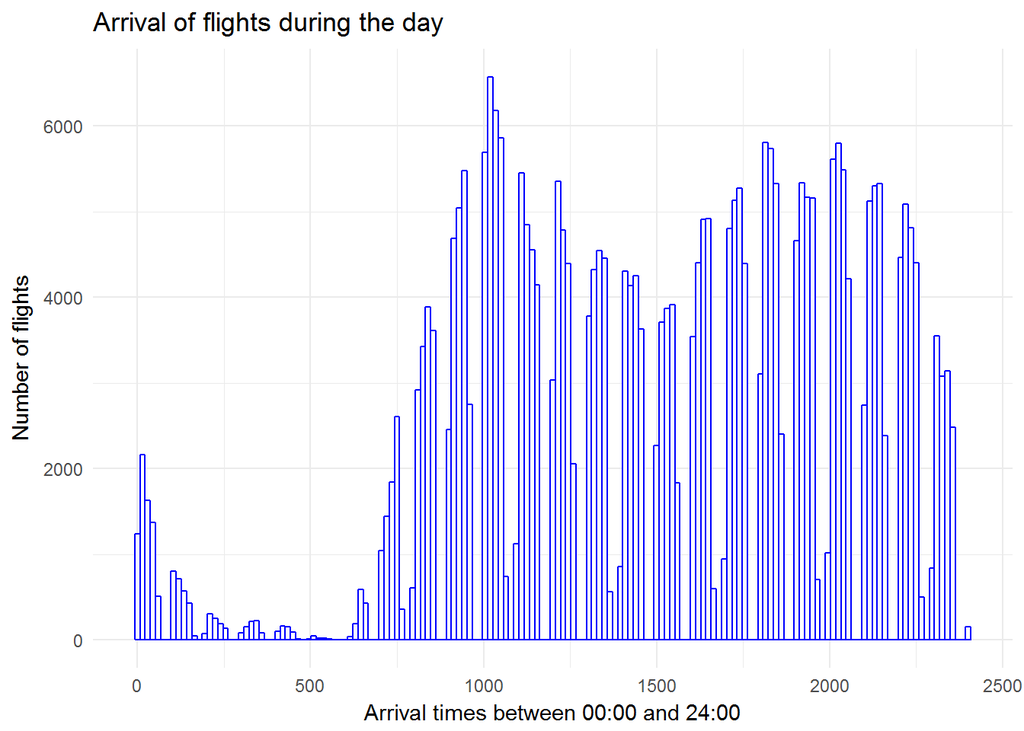

The below graphs shows the rather even distribution of the number of flights during the year per month with a minor setback in February.

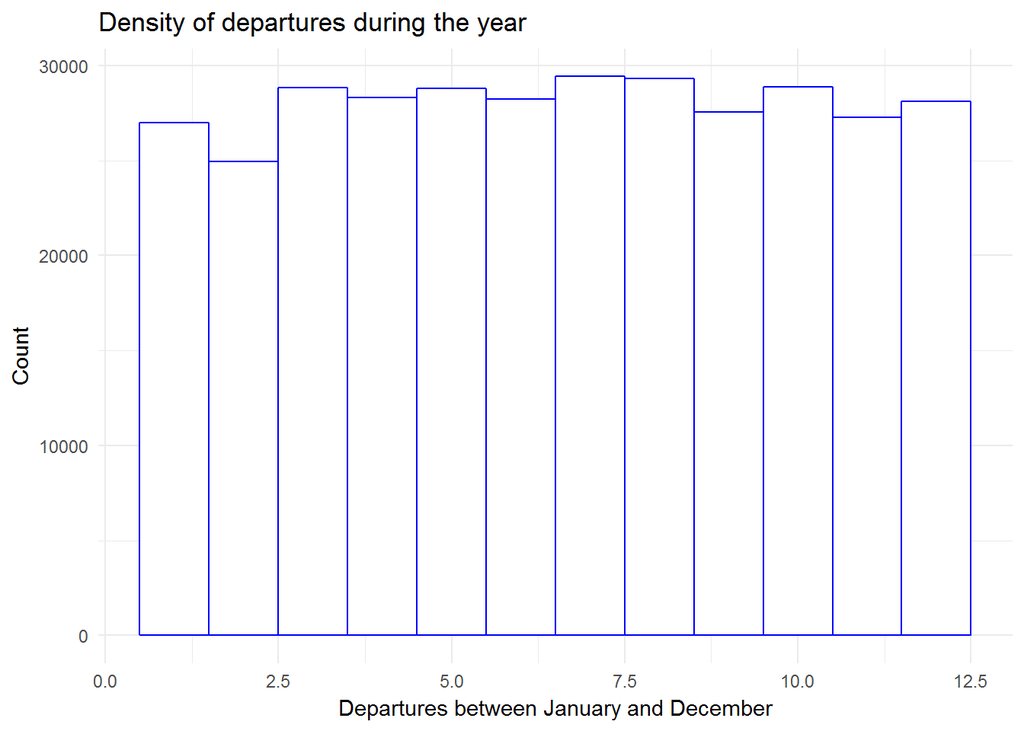

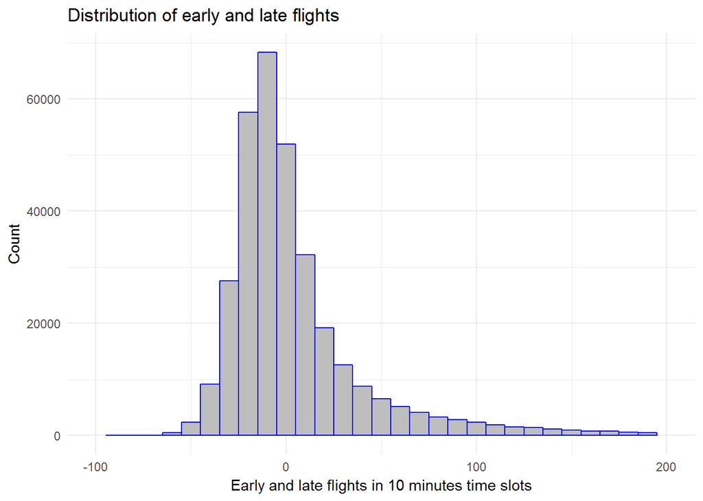

The distribution of total flights among carriers is provided by the below table, showing that UA, B6, EV and Delta carry cover most flights.

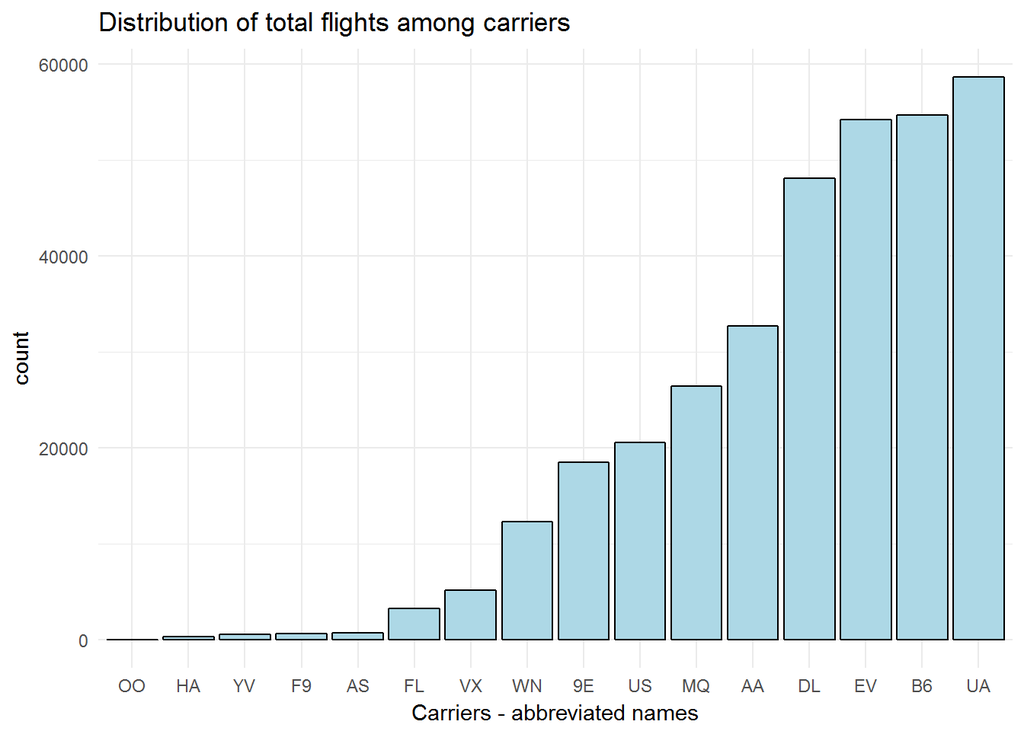

# The “planes” data set

This dataset provides for each plane: the tail number, year of manufacturing, type of the plane, the manufacturer, the model, number of engines, number of seats, the average cruising speed in mph and the type of engine.

At the data exploration phase a quick check of some basic information: The number of planes manufactured per year by engine type.

The belowchart shows that the planes are dominantly run with turbo-fan engines with some turbo jet engines. They are runnning planes built dominantly after 1983 with the peak year 2001.

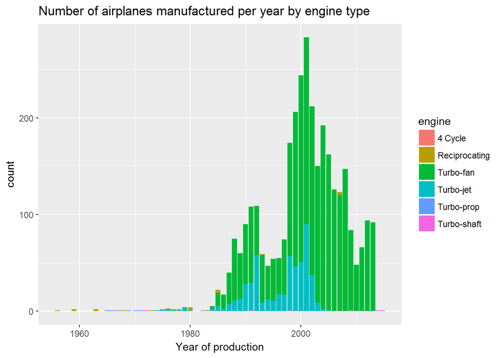

Note: we shall not use the airplanes data set for the model.

### 2. a model predicting if a flight will be late by 15+ minutes at the destination

To start with, some two-dimensional analysis of factors and delays:

**ANALYSIS OF DELAYS BASED ON THE EXTENDED FLIGHTS DATASET** **Altitude of destination airports & Arrival Delays**

```
## # A tibble: 1,458 × 8
##      faa                           name      lat        lon   alt    tz
##    <chr>                          <chr>    <dbl>      <dbl> <int> <dbl>
## 1    04G              Lansdowne Airport 41.13047  -80.61958  1044    -5
## 2    06A  Moton Field Municipal Airport 32.46057  -85.68003   264    -6
## 3    06C            Schaumburg Regional 41.98934  -88.10124   801    -6
## 4    06N                Randall Airport 41.43191  -74.39156   523    -5
## 5    09J          Jekyll Island Airport 31.07447  -81.42778    11    -5
## 6    0A9 Elizabethton Municipal Airport 36.37122  -82.17342  1593    -5
## 7    0G6        Williams County Airport 41.46731  -84.50678   730    -5
## 8    0G7  Finger Lakes Regional Airport 42.88356  -76.78123   492    -5
## 9    0P2   Shoestring Aviation Airfield 39.79482  -76.64719  1000    -5
## 10   0S9          Jefferson County Intl 48.05381 -122.81064   108    -8
## # ... with 1,448 more rows, and 2 more variables: dst <chr>, tzone <chr>
```

[output not shown]

**Longitude of destination airports & Arrival Delays**

[output not shown]

**Hour of Departure & Departure Delays**

Flights usually depart late in the afternoons with a peak at 20:00 p.m. Therefore this can be already an explanation why flights can be late at the destination.

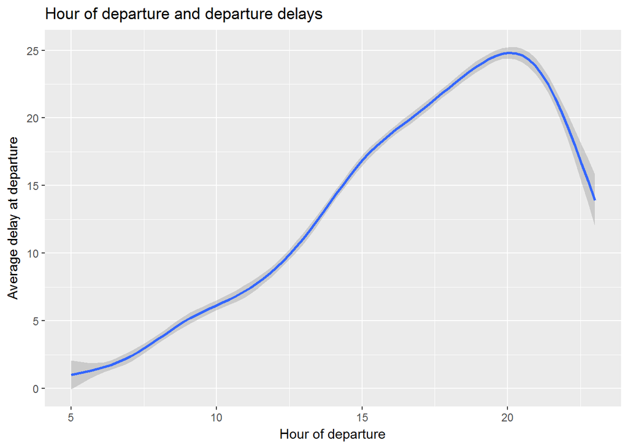

**Hour of Departure & Arrival Delays**

Flights tend to arrive early if the departure time is before 10.00 am. and the average delay of flights increases until 20:00 p.m. This chart with the previous one already provides a reason for late arrivals: airplanes depart late in the afternoon therefore there arrival is also late.

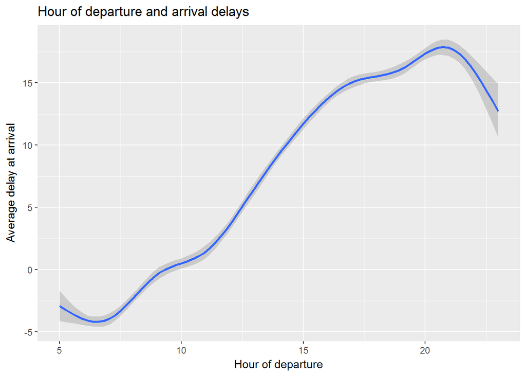

**Month of Departure & Departure Delays**

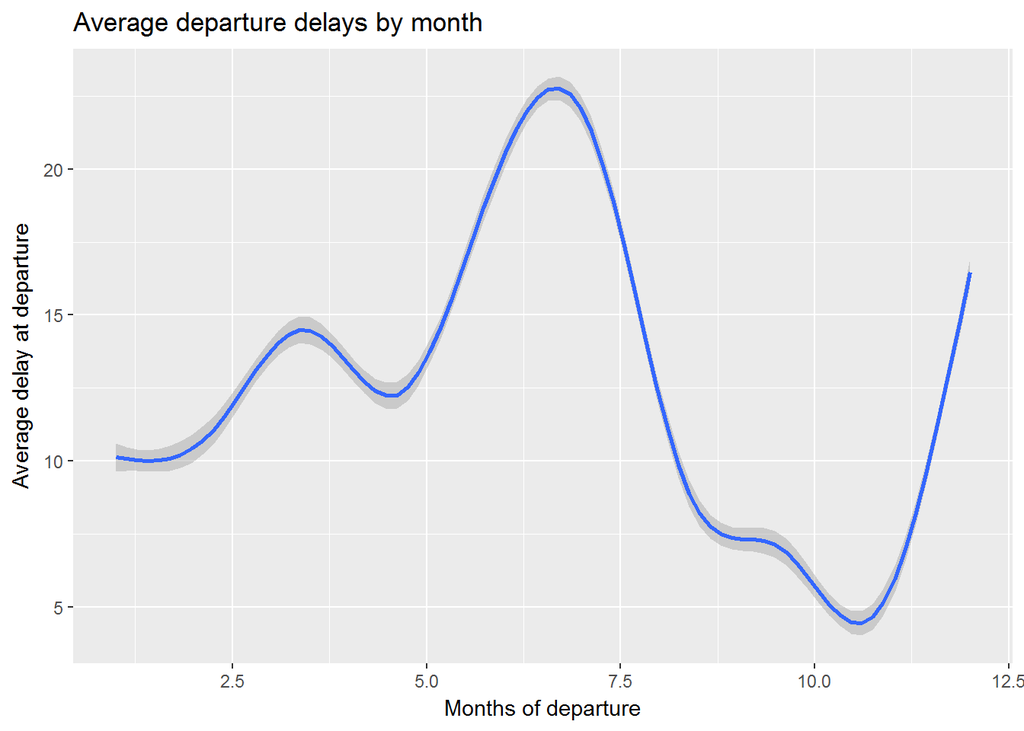

**Flight distance & arrival delays**

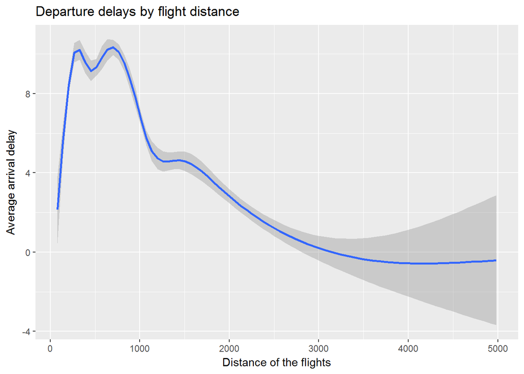

**Carriers & Arrival delays**

As the below boxplot shows, there is little difference between the average flight delays (or early arrivals) of the various carriers.

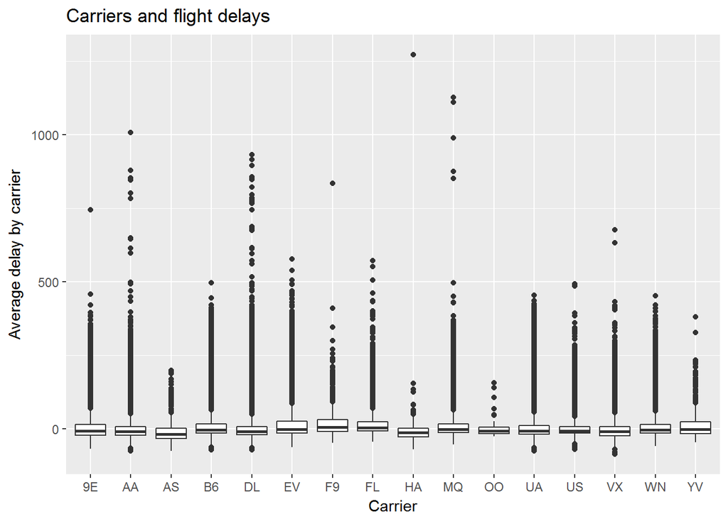

**Airports of origin & Arrival delays**

The airports of origin cannot provide an explanation for the delays as the boxplot shows for the three airports: JFK - New York, LaGuardia - New York and EWR - New Jersey.

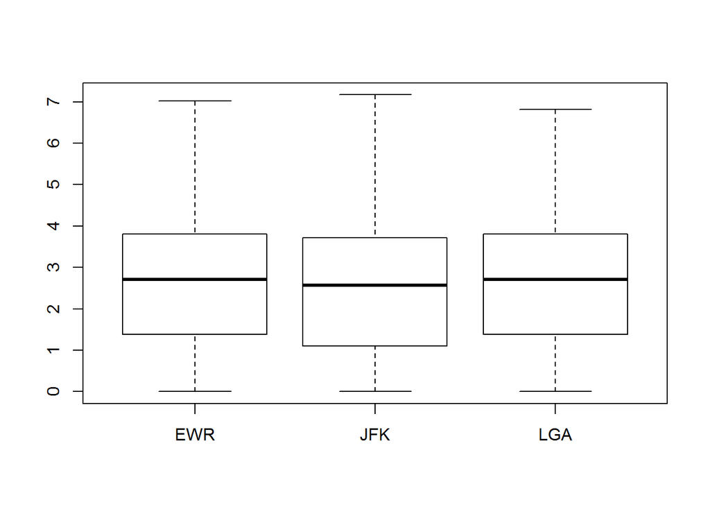